# maladie_cardio

Losseni SANGARE

2023-12-07

texte du rapport

# Regression logistique

Pour la partie 2 nous avons décidé de choisir nos propre données. Notre objectif sera d’appréhender les facteurs pouvant influencer l’apparition d’une maladie coronarienne à des fins de prévision.

```r
rm(list = ls())
df <- read.csv("D:/UTT/PROGRAMATION R/R intitiation/Projet/Dataset_Maladie_Cadiovasculaire.txt", row.names=1, sep=";")
View(df)
```

###Modelisatio de la regression logistique

```r
str(df)
```

```
## 'data.frame':    462 obs. of  10 variables:
##  $ sbp      : int  160 144 118 170 134 132 142 114 114 132 ...
##  $ tobacco  : num  12 0.01 0.08 7.5 13.6 6.2 4.05 4.08 0 0 ...
##  $ ldl      : num  5.73 4.41 3.48 6.41 3.5 6.47 3.38 4.59 3.83 5.8 ...
##  $ adiposity: num  23.1 28.6 32.3 38 27.8 ...
##  $ famhist  : chr  "Present" "Absent" "Present" "Present" ...
##  $ typea    : int  49 55 52 51 60 62 59 62 49 69 ...
##  $ obesity  : num  25.3 28.9 29.1 32 26 ...
##  $ alcohol  : num  97.2 2.06 3.81 24.26 57.34 ...
##  $ age      : int  52 63 46 58 49 45 38 58 29 53 ...
##  $ chd      : int  1 1 0 1 1 0 0 1 0 1 ...
```

```r
summary(df)
```

```
##       sbp           tobacco             ldl           adiposity
##  Min.   :101.0   Min.   : 0.0000   Min.   : 0.980   Min.   : 6.74
##  1st Qu.:124.0   1st Qu.: 0.0525   1st Qu.: 3.283   1st Qu.:19.77
##  Median :134.0   Median : 2.0000   Median : 4.340   Median :26.11
##  Mean   :138.3   Mean   : 3.6356   Mean   : 4.740   Mean   :25.41
##  3rd Qu.:148.0   3rd Qu.: 5.5000   3rd Qu.: 5.790   3rd Qu.:31.23
##  Max.   :218.0   Max.   :31.2000   Max.   :15.330   Max.   :42.49
##    famhist              typea         obesity         alcohol
##  Length:462         Min.   :13.0   Min.   :14.70   Min.   :  0.00
##  Class :character   1st Qu.:47.0   1st Qu.:22.98   1st Qu.:  0.51
##  Mode  :character   Median :53.0   Median :25.80   Median :  7.51
##                     Mean   :53.1   Mean   :26.04   Mean   : 17.04
##                     3rd Qu.:60.0   3rd Qu.:28.50   3rd Qu.: 23.89
##                     Max.   :78.0   Max.   :46.58   Max.   :147.19
##       age             chd
##  Min.   :15.00   Min.   :0.0000
##  1st Qu.:31.00   1st Qu.:0.0000
##  Median :45.00   Median :0.0000
##  Mean   :42.82   Mean   :0.3463
##  3rd Qu.:55.00   3rd Qu.:1.0000
##  Max.   :64.00   Max.   :1.0000
```

```r
rlg = glm(df$chd~.,data = df,family = binomial)
```

```r
summary(rlg)
```

```
##
## Call:
## glm(formula = df$chd ~ ., family = binomial, data = df)
##
## Coefficients:
##                  Estimate Std. Error z value Pr(>|z|)
## (Intercept)    -6.1507209  1.3082600  -4.701 2.58e-06 ***
## sbp             0.0065040  0.0057304   1.135 0.256374
## tobacco         0.0793764  0.0266028   2.984 0.002847 **
## ldl             0.1739239  0.0596617   2.915 0.003555 **
## adiposity       0.0185866  0.0292894   0.635 0.525700
## famhistPresent  0.9253704  0.2278940   4.061 4.90e-05 ***
## typea           0.0395950  0.0123202   3.214 0.001310 **
## obesity        -0.0629099  0.0442477  -1.422 0.155095
## alcohol         0.0001217  0.0044832   0.027 0.978350
## age             0.0452253  0.0121298   3.728 0.000193 ***
## ---
## Signif. codes:  0 '***' 0.001 '**' 0.01 '*' 0.05 '.' 0.1 ' ' 1
##
## (Dispersion parameter for binomial family taken to be 1)
##
##     Null deviance: 596.11  on 461  degrees of freedom
## Residual deviance: 472.14  on 452  degrees of freedom
## AIC: 492.14
##
## Number of Fisher Scoring iterations: 5
```

###Analyse on remarque une bonne estimation pour intercept avec un p-value tres inférieur a 0.05 aussi pour les coéficiant des varible independate famhistPresent, age ensuite tobacco,ldl,typea.

```r
prev = predict(rlg, type = "response")
head(df$chd)
```

```
## [1] 1 1 0 1 1 0
```

```r
head(prev)
```

```
##         1         2         3         4         5         6
## 0.7121829 0.3310109 0.2809570 0.7171233 0.6930608 0.6176621
```

```r
prev=as.numeric(prev>0.5)
head(prev)
```

```
## [1] 1 0 0 1 1 1
```

###choix de variable

```r
final_rlg =step(rlg)
```

```
## Start:  AIC=492.14
## df$chd ~ sbp + tobacco + ldl + adiposity + famhist + typea +
##     obesity + alcohol + age
##
##             Df Deviance    AIC
## - alcohol    1   472.14 490.14
## - adiposity  1   472.55 490.55
## - sbp        1   473.44 491.44
## <none>           472.14 492.14
## - obesity    1   474.23 492.23
## - ldl        1   481.07 499.07
## - tobacco    1   481.67 499.67
## - typea      1   483.05 501.05
## - age        1   486.53 504.53
## - famhist    1   488.89 506.89
##
## Step:  AIC=490.14
## df$chd ~ sbp + tobacco + ldl + adiposity + famhist + typea +
##     obesity + age
##
##             Df Deviance    AIC
## - adiposity  1   472.55 488.55
## - sbp        1   473.47 489.47
## <none>           472.14 490.14
## - obesity    1   474.24 490.24
## - ldl        1   481.15 497.15
## - tobacco    1   482.06 498.06
## - typea      1   483.06 499.06
## - age        1   486.64 502.64
## - famhist    1   488.99 504.99
##
## Step:  AIC=488.55
## df$chd ~ sbp + tobacco + ldl + famhist + typea + obesity + age
##
##           Df Deviance    AIC
## - sbp      1   473.98 487.98
## <none>         472.55 488.55
## - obesity  1   474.65 488.65
## - tobacco  1   482.54 496.54
## - ldl      1   482.95 496.95
```

[output cut: 11 more lines]

```
## - typea    1   484.30 496.30
## - ldl      1   484.53 496.53
## - famhist  1   490.58 502.58
## - age      1   502.11 514.11
##
## Step:  AIC=487.69
## df$chd ~ tobacco + ldl + famhist + typea + age
##
##           Df Deviance    AIC
## <none>         475.69 487.69
## - ldl      1   484.71 494.71
## - typea    1   485.44 495.44
## - tobacco  1   486.03 496.03
## - famhist  1   492.09 502.09
## - age      1   502.38 512.38
```

```r
step_rlg=glm(df$chd ~ tobacco + ldl + famhist + typea + age, data = df,family=binomial)
summary(step_rlg)
```

```
##
## Call:
## glm(formula = df$chd ~ tobacco + ldl + famhist + typea + age,
##     family = binomial, data = df)
##
## Coefficients:
##                Estimate Std. Error z value Pr(>|z|)
## (Intercept)    -6.44644    0.92087  -7.000 2.55e-12 ***
## tobacco         0.08038    0.02588   3.106  0.00190 **
## ldl             0.16199    0.05497   2.947  0.00321 **
## famhistPresent  0.90818    0.22576   4.023 5.75e-05 ***
## typea           0.03712    0.01217   3.051  0.00228 **
## age             0.05046    0.01021   4.944 7.65e-07 ***
## ---
## Signif. codes:  0 '***' 0.001 '**' 0.01 '*' 0.05 '.' 0.1 ' ' 1
##
## (Dispersion parameter for binomial family taken to be 1)
##
##     Null deviance: 596.11  on 461  degrees of freedom
## Residual deviance: 475.69  on 456  degrees of freedom
## AIC: 487.69
##
## Number of Fisher Scoring iterations: 5
```

##Analyse Avec seulement 5 variables independante on remarque que l’AIC est passé a 487,69 qui inférieur à 492,14 obténu auparavant avec toutes les varibles independante.

```r
prev2 =predict(step_rlg,type = "response")
head(df$chd)
```

```
## [1] 1 1 0 1 1 0
```

```r
head(prev)
```

```
## [1] 1 0 0 1 1 1
```

```r
prev2=as.numeric(prev2>0.5)
head(prev2)
```

```
## [1] 1 0 0 1 1 1
```

```r
table(df$chd)
```

```
##
##   0   1
## 302 160
```

```r
table(prev)
```

```
## prev
##   0   1
## 333 129
```

```r
table(prev2)
```

```
## prev2
##   0   1
## 329 133
```

```r
mean(prev==df$chd)
```

```
## [1] 0.7337662
```

```r
mean(prev2==df$chd)
```

```
## [1] 0.7424242
```

on remarque une que le model avec les 5 variables a une précision supérieur à celui du prémier model soit 74,24 % contre 73,37%

## Table de confusion

```r
table(prev2,df$chd)
```

```
##
## prev2   0   1
##     0 256  73
##     1  46  87
```

on a 256 vrai négatif et 87 vrai positif

#Arbre de décision

```r
rm(list=ls())
df <- read.csv("D:/UTT/PROGRAMATION R/R intitiation/Projet/Dataset_Maladie_Cadiovasculaire.txt", row.names=1, sep=";")
View(df)
#df = mutate(df,chd=case_when(chd==1~"yes", chd==0~"no"))

library(rpart)
arbre = rpart(chd~.,data = df, cp=0.013, method = "class")
arbre
```

```
## n= 462
##
## node), split, n, loss, yval, (yprob)
##       * denotes terminal node
##
##  1) root 462 160 0 (0.65367965 0.34632035)
##    2) age< 50.5 290  64 0 (0.77931034 0.22068966)
##      4) age< 30.5 108   8 0 (0.92592593 0.07407407) *
##      5) age>=30.5 182  56 0 (0.69230769 0.30769231)
##       10) typea< 68.5 170  46 0 (0.72941176 0.27058824) *
##       11) typea>=68.5 12   2 1 (0.16666667 0.83333333) *
##    3) age>=50.5 172  76 1 (0.44186047 0.55813953)
##      6) famhist=Absent 82  33 0 (0.59756098 0.40243902)
##       12) tobacco< 7.605 58  16 0 (0.72413793 0.27586207) *
##       13) tobacco>=7.605 24   7 1 (0.29166667 0.70833333) *
##      7) famhist=Present 90  27 1 (0.30000000 0.70000000)
##       14) ldl< 4.99 39  18 1 (0.46153846 0.53846154)
##         28) adiposity>=27.985 20   7 0 (0.65000000 0.35000000) *
##         29) adiposity< 27.985 19   5 1 (0.26315789 0.73684211) *
##       15) ldl>=4.99 51   9 1 (0.17647059 0.82352941) *
```

##Affichage de l’arbre

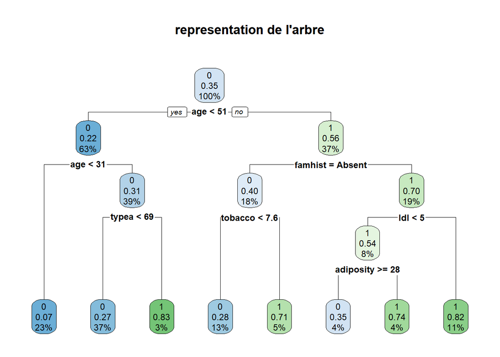

```r
library(rpart.plot)
rpart.plot(arbre, main="representation de l'arbre")
```

## verification de la performance du modele

```r
pred_arb = predict(arbre,data=df, type = "class")

table(df$chd)
```

```
##
##   0   1
## 302 160
```

```r
table(pred_arb)
```

```
## pred_arb
##   0   1
## 356 106
```

```r
mean(pred_arb==df$chd)
```

```
## [1] 0.7835498
```

l’arbre de décision prédir explique mieux chd par rapport a la regression logistique. En effet nous avons une precisicion de 78,35% contre 74,24%.

##Table de confusion

```r
table(pred_arb,df$chd)
```

```
##
## pred_arb   0   1
##        0 279  77
##        1  23  83
```

ce modele nous donne 279 vrai négatifs et 83 vrai positif